# Movies wk 9 adjustmnets

Introduction Question 1 Question 2 Question ... Data Wrangle Data analysis Conclusion Limitation

Investigatnig a data set. Alex Challenor

Data import: Data set is: -TMDb movie data

Data location: https://www.google.com/url?q=https://d17h27t6h515a5.cloudfront.net/topher/2017/October/59dd1c4c_tmdb-movies/tmdb-movies.csv&sa=D&ust=1532469042115000

Explanation of the data set: This data set contain data of 10866 diffrent films and key item of data about each one.

```python
import numpy as np
import pandas as pd
import matplotlib as mp

master_data = pd.read_csv("tmdb-movies.csv")
```

```python
master_data.head(3)
```

|  | id | imdb_id | popularity | budget | revenue | original_title | cast | homepage | director | tagline | ... | overview | runtime | genres | production_companies | release_date | vote_count | vote_average | release_year | budget_adj | revenue_adj |
| --- | --- | --- | --- | --- | --- | --- | --- | --- | --- | --- | --- | --- | --- | --- | --- | --- | --- | --- | --- | --- | --- |
| 0 | 135397 | tt0369610 | 32.985763 | 150000000 | 1513528810 | Jurassic World | Chris Pratt\|Bryce Dallas Howard\|Irrfan Khan\|Vi... | http://www.jurassicworld.com/ | Colin Trevorrow | The park is open. | ... | Twenty-two years after the events of Jurassic ... | 124 | Action\|Adventure\|Science Fiction\|Thriller | Universal Studios\|Amblin Entertainment\|Legenda... | 6/9/15 | 5562 | 6.5 | 2015 | 1.379999e+08 | 1.392446e+09 |
| 1 | 76341 | tt1392190 | 28.419936 | 150000000 | 378436354 | Mad Max: Fury Road | Tom Hardy\|Charlize Theron\|Hugh Keays-Byrne\|Nic... | http://www.madmaxmovie.com/ | George Miller | What a Lovely Day. | ... | An apocalyptic story set in the furthest reach... | 120 | Action\|Adventure\|Science Fiction\|Thriller | Village Roadshow Pictures\|Kennedy Miller Produ... | 5/13/15 | 6185 | 7.1 | 2015 | 1.379999e+08 | 3.481613e+08 |
| 2 | 262500 | tt2908446 | 13.112507 | 110000000 | 295238201 | Insurgent | Shailene Woodley\|Theo James\|Kate Winslet\|Ansel... | http://www.thedivergentseries.movie/#insurgent | Robert Schwentke | One Choice Can Destroy You | ... | Beatrice Prior must confront her inner demons ... | 119 | Adventure\|Science Fiction\|Thriller | Summit Entertainment\|Mandeville Films\|Red Wago... | 3/18/15 | 2480 | 6.3 | 2015 | 1.012000e+08 | 2.716190e+08 |

3 rows × 21 columns

```python
#find out how many data rows in data set.
len(master_data)
```

```
10866
```

Introduction:

I will use Jupyter Note book to investigate the data set and invesigate the follwing questions using python.

Question 1 - What is the most common film genre over the years from 1960-2015. This will be my 1D question.

Question 2 - What is the most common Film genre per year. This will be my 2D question.

Data Wrangling:

To answer the questions i will need to "wrangle" the data to get it into a position where i can analyse it and draw a conclusion.

The following tasks are conducted in code cells below:

- Convert date into a time/date format
  - Alow the python code to read the data as date format not a sting value
- Spit out the diffrent genras from the Genres column
  - The Genrea column is filled with many values in a "string type". I will split the genres up into indivisual values which will allow for analysis later in project.
- Check for any Genre cells with no data in
  - Use this knowledge when making a conclusion
- Use "group by" to organise that data to allow a conclusion and graph to be made.

```python
#change string to date format
master_data['release_date'] = pd.to_datetime(master_data['release_date'],)

master_data.head(3)
```

|  | id | imdb_id | popularity | budget | revenue | original_title | cast | homepage | director | tagline | ... | overview | runtime | genres | production_companies | release_date | vote_count | vote_average | release_year | budget_adj | revenue_adj |
| --- | --- | --- | --- | --- | --- | --- | --- | --- | --- | --- | --- | --- | --- | --- | --- | --- | --- | --- | --- | --- | --- |
| 0 | 135397 | tt0369610 | 32.985763 | 150000000 | 1513528810 | Jurassic World | Chris Pratt\|Bryce Dallas Howard\|Irrfan Khan\|Vi... | http://www.jurassicworld.com/ | Colin Trevorrow | The park is open. | ... | Twenty-two years after the events of Jurassic ... | 124 | Action\|Adventure\|Science Fiction\|Thriller | Universal Studios\|Amblin Entertainment\|Legenda... | 2015-06-09 | 5562 | 6.5 | 2015 | 1.379999e+08 | 1.392446e+09 |
| 1 | 76341 | tt1392190 | 28.419936 | 150000000 | 378436354 | Mad Max: Fury Road | Tom Hardy\|Charlize Theron\|Hugh Keays-Byrne\|Nic... | http://www.madmaxmovie.com/ | George Miller | What a Lovely Day. | ... | An apocalyptic story set in the furthest reach... | 120 | Action\|Adventure\|Science Fiction\|Thriller | Village Roadshow Pictures\|Kennedy Miller Produ... | 2015-05-13 | 6185 | 7.1 | 2015 | 1.379999e+08 | 3.481613e+08 |
| 2 | 262500 | tt2908446 | 13.112507 | 110000000 | 295238201 | Insurgent | Shailene Woodley\|Theo James\|Kate Winslet\|Ansel... | http://www.thedivergentseries.movie/#insurgent | Robert Schwentke | One Choice Can Destroy You | ... | Beatrice Prior must confront her inner demons ... | 119 | Adventure\|Science Fiction\|Thriller | Summit Entertainment\|Mandeville Films\|Red Wago... | 2015-03-18 | 2480 | 6.3 | 2015 | 1.012000e+08 | 2.716190e+08 |

3 rows × 21 columns

```python
# shows how many rows have no Genre data in this column
master_data['genres'].isnull().sum()
```

```
23
```

```python
#create a new table with the genre data delimitd and split

data_with_genres_split = master_data["genres"].str.split("|", n = 9, expand = True)
data_with_genres_split.head(5)
```

|  | 0 | 1 | 2 | 3 | 4 |
| --- | --- | --- | --- | --- | --- |
| 0 | Action | Adventure | Science Fiction | Thriller | None |
| 1 | Action | Adventure | Science Fiction | Thriller | None |
| 2 | Adventure | Science Fiction | Thriller | None | None |
| 3 | Action | Adventure | Science Fiction | Fantasy | None |
| 4 | Action | Crime | Thriller | None | None |

```python
#Check this has worked on every data line. expected value is 10866

len(data_with_genres_split)
```

```
10866
```

```python
#change column names to more usefull not just 0-4

data_with_genres_split.columns = ['genre1','genre2','genre3','genre4','genre5']
data_with_genres_split.head()
```

|  | genre1 | genre2 | genre3 | genre4 | genre5 |
| --- | --- | --- | --- | --- | --- |
| 0 | Action | Adventure | Science Fiction | Thriller | None |
| 1 | Action | Adventure | Science Fiction | Thriller | None |
| 2 | Adventure | Science Fiction | Thriller | None | None |
| 3 | Action | Adventure | Science Fiction | Fantasy | None |
| 4 | Action | Crime | Thriller | None | None |

```python
#concat the two tables to add indivdual genres columns on to the end of the dataframe
genres_concat = pd.concat([master_data, data_with_genres_split],axis=1)

genres_concat.head(5)
```

|  | id | imdb_id | popularity | budget | revenue | original_title | cast | homepage | director | tagline | ... | vote_count | vote_average | release_year | budget_adj | revenue_adj | genre1 | genre2 | genre3 | genre4 | genre5 |
| --- | --- | --- | --- | --- | --- | --- | --- | --- | --- | --- | --- | --- | --- | --- | --- | --- | --- | --- | --- | --- | --- |
| 0 | 135397 | tt0369610 | 32.985763 | 150000000 | 1513528810 | Jurassic World | Chris Pratt\|Bryce Dallas Howard\|Irrfan Khan\|Vi... | http://www.jurassicworld.com/ | Colin Trevorrow | The park is open. | ... | 5562 | 6.5 | 2015 | 1.379999e+08 | 1.392446e+09 | Action | Adventure | Science Fiction | Thriller | None |
| 1 | 76341 | tt1392190 | 28.419936 | 150000000 | 378436354 | Mad Max: Fury Road | Tom Hardy\|Charlize Theron\|Hugh Keays-Byrne\|Nic... | http://www.madmaxmovie.com/ | George Miller | What a Lovely Day. | ... | 6185 | 7.1 | 2015 | 1.379999e+08 | 3.481613e+08 | Action | Adventure | Science Fiction | Thriller | None |
| 2 | 262500 | tt2908446 | 13.112507 | 110000000 | 295238201 | Insurgent | Shailene Woodley\|Theo James\|Kate Winslet\|Ansel... | http://www.thedivergentseries.movie/#insurgent | Robert Schwentke | One Choice Can Destroy You | ... | 2480 | 6.3 | 2015 | 1.012000e+08 | 2.716190e+08 | Adventure | Science Fiction | Thriller | None | None |
| 3 | 140607 | tt2488496 | 11.173104 | 200000000 | 2068178225 | Star Wars: The Force Awakens | Harrison Ford\|Mark Hamill\|Carrie Fisher\|Adam D... | http://www.starwars.com/films/star-wars-episod... | J.J. Abrams | Every generation has a story. | ... | 5292 | 7.5 | 2015 | 1.839999e+08 | 1.902723e+09 | Action | Adventure | Science Fiction | Fantasy | None |
| 4 | 168259 | tt2820852 | 9.335014 | 190000000 | 1506249360 | Furious 7 | Vin Diesel\|Paul Walker\|Jason Statham\|Michelle ... | http://www.furious7.com/ | James Wan | Vengeance Hits Home | ... | 2947 | 7.3 | 2015 | 1.747999e+08 | 1.385749e+09 | Action | Crime | Thriller | None | None |

5 rows × 26 columns

```python
#create a new list of all the genre values from table above
genre_list_new = pd.concat([genres_concat['genre1'],genres_concat['genre2'],genres_concat['genre3'],genres_concat['genre4'],genres_concat['genre5']], ignore_index=True)

genre_list_new.head()
len(genre_list_new)
```

```
54330
```

```python
#have alist now of all the readings. pass this list into a function into it.
```

```python
#totals of the grenre counts. Drama is top of the list so i suspect this will be very common for most common genre
genre_count = genre_list_new.value_counts()

print (genre_count)
```

```
Drama              4761
Comedy             3793
Thriller           2908
Action             2385
Romance            1712
Horror             1637
Adventure          1471
Crime              1355
Family             1231
Science Fiction    1230
Fantasy             916
Mystery             810
Animation           699
Documentary         520
Music               408
History             334
War                 270
Foreign             188
TV Movie            167
Western             165
dtype: int64
```

The data above states that Drama is the most popular genre over the sample times. More details in the conclusion

```python
#Now sort the above list aphabeticaly
genre_sort = genre_count.rename_axis('genre')
genre_sort.sort_index(inplace = True)
print (genre_sort)
```

```
genre
Action             2385
Adventure          1471
Animation           699
Comedy             3793
Crime              1355
Documentary         520
Drama              4761
Family             1231
Fantasy             916
Foreign             188
History             334
Horror             1637
Music               408
Mystery             810
Romance            1712
Science Fiction    1230
TV Movie            167
Thriller           2908
War                 270
Western             165
dtype: int64
```

```python
#For each genre add Ture or False if that genre is applicable to the row.
genres_concat['Action'] = genres_concat['genres'].str.contains('Action')
genres_concat['Adventure'] = genres_concat['genres'].str.contains('Adventure')
genres_concat['Animation'] = genres_concat['genres'].str.contains('Animation')
genres_concat['Comedy'] = genres_concat['genres'].str.contains('Comedy')
genres_concat['Crime'] = genres_concat['genres'].str.contains('Crime')
genres_concat['Documentary'] = genres_concat['genres'].str.contains('Documentary')
genres_concat['Drama'] = genres_concat['genres'].str.contains('Drama')
genres_concat['Family'] = genres_concat['genres'].str.contains('Family')
genres_concat['Fantasy'] = genres_concat['genres'].str.contains('Fantasy')
genres_concat['Foreign'] = genres_concat['genres'].str.contains('Foreign')
genres_concat['History'] = genres_concat['genres'].str.contains('History')
genres_concat['Horror'] = genres_concat['genres'].str.contains('Horror')
genres_concat['Music'] = genres_concat['genres'].str.contains('Music')
genres_concat['Mystery'] = genres_concat['genres'].str.contains('Mystery')
genres_concat['Romance'] = genres_concat['genres'].str.contains('Romance')
genres_concat['Science Fiction'] = genres_concat['genres'].str.contains('Science Fiction')
genres_concat['TV Movie'] = genres_concat['genres'].str.contains('TV Movie')
genres_concat['Thriller'] = genres_concat['genres'].str.contains('Thriller')
genres_concat['War'] = genres_concat['genres'].str.contains('War')
genres_concat['Western'] = genres_concat['genres'].str.contains('Western')


genres_concat.head()
```

|  | id | imdb_id | popularity | budget | revenue | original_title | cast | homepage | director | tagline | ... | History | Horror | Music | Mystery | Romance | Science Fiction | TV Movie | Thriller | War | Western |
| --- | --- | --- | --- | --- | --- | --- | --- | --- | --- | --- | --- | --- | --- | --- | --- | --- | --- | --- | --- | --- | --- |
| 0 | 135397 | tt0369610 | 32.985763 | 150000000 | 1513528810 | Jurassic World | Chris Pratt\|Bryce Dallas Howard\|Irrfan Khan\|Vi... | http://www.jurassicworld.com/ | Colin Trevorrow | The park is open. | ... | False | False | False | False | False | True | False | True | False | False |
| 1 | 76341 | tt1392190 | 28.419936 | 150000000 | 378436354 | Mad Max: Fury Road | Tom Hardy\|Charlize Theron\|Hugh Keays-Byrne\|Nic... | http://www.madmaxmovie.com/ | George Miller | What a Lovely Day. | ... | False | False | False | False | False | True | False | True | False | False |
| 2 | 262500 | tt2908446 | 13.112507 | 110000000 | 295238201 | Insurgent | Shailene Woodley\|Theo James\|Kate Winslet\|Ansel... | http://www.thedivergentseries.movie/#insurgent | Robert Schwentke | One Choice Can Destroy You | ... | False | False | False | False | False | True | False | True | False | False |
| 3 | 140607 | tt2488496 | 11.173104 | 200000000 | 2068178225 | Star Wars: The Force Awakens | Harrison Ford\|Mark Hamill\|Carrie Fisher\|Adam D... | http://www.starwars.com/films/star-wars-episod... | J.J. Abrams | Every generation has a story. | ... | False | False | False | False | False | True | False | False | False | False |
| 4 | 168259 | tt2820852 | 9.335014 | 190000000 | 1506249360 | Furious 7 | Vin Diesel\|Paul Walker\|Jason Statham\|Michelle ... | http://www.furious7.com/ | James Wan | Vengeance Hits Home | ... | False | False | False | False | False | False | False | True | False | False |

5 rows × 46 columns

```python
#group the data for each year
genres_concat.groupby(['release_year'])['Action','Adventure','Animation','Comedy','Crime', 'Documentary','Drama','Family','Fantasy','Foreign','History','Horror','Music','Mystery','Romance','Science Fiction','TV Movie','Thriller','War','Western'].sum()
```

| release_year | Action | Adventure | Animation | Comedy | Crime | Documentary | Drama | Family | Fantasy | Foreign | History | Horror | Music | Mystery | Romance | Science Fiction | TV Movie | Thriller | War | Western |
| --- | --- | --- | --- | --- | --- | --- | --- | --- | --- | --- | --- | --- | --- | --- | --- | --- | --- | --- | --- | --- |
| 1960 | 8 | 5 | 0 | 8 | 2 | 0 | 13 | 3 | 2 | 1 | 5 | 7 | 1 | 0 | 6 | 3 | 0 | 6 | 2 | 6 |
| 1961 | 7 | 6 | 1 | 10 | 2 | 0 | 16 | 5 | 2 | 1 | 3 | 3 | 2 | 1 | 7 | 4 | 0 | 0 | 2 | 3 |
| 1962 | 8 | 7 | 0 | 5 | 3 | 0 | 21 | 2 | 1 | 1 | 4 | 5 | 1 | 4 | 5 | 2 | 0 | 7 | 3 | 3 |
| 1963 | 4 | 7 | 1 | 13 | 4 | 0 | 13 | 3 | 2 | 2 | 4 | 9 | 0 | 6 | 8 | 2 | 0 | 10 | 1 | 2 |
| 1964 | 5 | 5 | 2 | 16 | 10 | 0 | 20 | 4 | 4 | 1 | 3 | 6 | 5 | 4 | 9 | 4 | 0 | 9 | 3 | 1 |
| 1965 | 9 | 6 | 1 | 7 | 2 | 0 | 20 | 3 | 0 | 1 | 4 | 5 | 2 | 3 | 5 | 2 | 1 | 11 | 8 | 4 |
| 1966 | 14 | 11 | 3 | 16 | 5 | 1 | 16 | 7 | 2 | 2 | 2 | 3 | 0 | 6 | 6 | 6 | 0 | 8 | 4 | 7 |
| 1967 | 7 | 7 | 2 | 17 | 7 | 1 | 16 | 3 | 3 | 0 | 0 | 4 | 5 | 3 | 11 | 4 | 0 | 5 | 1 | 2 |
| 1968 | 6 | 5 | 3 | 9 | 5 | 0 | 20 | 5 | 5 | 0 | 3 | 4 | 3 | 4 | 6 | 4 | 0 | 5 | 4 | 1 |
| 1969 | 10 | 5 | 3 | 12 | 3 | 0 | 13 | 4 | 2 | 0 | 3 | 1 | 2 | 1 | 4 | 3 | 1 | 3 | 3 | 7 |
| 1970 | 11 | 6 | 2 | 12 | 4 | 3 | 19 | 3 | 3 | 1 | 3 | 5 | 4 | 3 | 6 | 3 | 1 | 5 | 5 | 8 |
| 1971 | 11 | 5 | 1 | 9 | 10 | 0 | 30 | 2 | 2 | 0 | 3 | 7 | 1 | 6 | 9 | 6 | 1 | 17 | 4 | 5 |
| 1972 | 10 | 5 | 1 | 13 | 7 | 1 | 16 | 2 | 1 | 0 | 0 | 8 | 2 | 4 | 5 | 4 | 0 | 10 | 0 | 5 |
| 1973 | 15 | 5 | 3 | 8 | 17 | 1 | 31 | 4 | 1 | 0 | 2 | 15 | 1 | 7 | 3 | 6 | 1 | 16 | 0 | 4 |
| 1974 | 14 | 8 | 1 | 12 | 15 | 2 | 21 | 4 | 3 | 0 | 1 | 8 | 1 | 5 | 4 | 5 | 1 | 20 | 1 | 2 |
| 1975 | 10 | 8 | 1 | 12 | 6 | 1 | 17 | 2 | 4 | 0 | 3 | 8 | 3 | 8 | 2 | 11 | 0 | 13 | 2 | 3 |
| 1976 | 13 | 6 | 0 | 12 | 8 | 1 | 22 | 3 | 2 | 1 | 2 | 9 | 3 | 7 | 5 | 5 | 1 | 17 | 2 | 3 |
| 1977 | 14 | 15 | 5 | 11 | 2 | 1 | 24 | 8 | 9 | 0 | 4 | 14 | 3 | 5 | 4 | 11 | 0 | 12 | 4 | 1 |
| 1978 | 15 | 11 | 2 | 14 | 6 | 3 | 29 | 6 | 5 | 1 | 2 | 19 | 3 | 7 | 5 | 16 | 3 | 22 | 4 | 1 |
| 1979 | 8 | 8 | 1 | 19 | 8 | 0 | 30 | 5 | 0 | 0 | 3 | 11 | 4 | 4 | 8 | 10 | 0 | 16 | 3 | 4 |
| 1980 | 27 | 14 | 0 | 25 | 9 | 0 | 32 | 4 | 7 | 2 | 5 | 16 | 4 | 9 | 9 | 11 | 1 | 25 | 2 | 5 |
| 1981 | 17 | 14 | 3 | 20 | 10 | 2 | 32 | 5 | 3 | 0 | 5 | 24 | 3 | 10 | 10 | 10 | 1 | 27 | 2 | 0 |
| 1982 | 17 | 10 | 6 | 28 | 9 | 1 | 33 | 8 | 13 | 2 | 2 | 20 | 6 | 10 | 12 | 13 | 1 | 17 | 2 | 2 |
| 1983 | 21 | 14 | 3 | 28 | 11 | 0 | 35 | 4 | 10 | 1 | 1 | 13 | 5 | 5 | 14 | 16 | 1 | 24 | 1 | 1 |
| 1984 | 33 | 22 | 1 | 38 | 15 | 2 | 40 | 9 | 15 | 0 | 5 | 18 | 11 | 4 | 19 | 27 | 1 | 24 | 3 | 0 |
| 1985 | 28 | 28 | 2 | 51 | 14 | 1 | 40 | 12 | 14 | 0 | 1 | 14 | 2 | 3 | 21 | 17 | 0 | 24 | 2 | 3 |
| 1986 | 30 | 17 | 7 | 49 | 18 | 0 | 51 | 13 | 11 | 0 | 3 | 30 | 6 | 7 | 25 | 21 | 0 | 23 | 4 | 1 |
| 1987 | 29 | 17 | 4 | 57 | 21 | 0 | 52 | 16 | 18 | 0 | 3 | 25 | 4 | 7 | 24 | 18 | 2 | 28 | 6 | 1 |
| 1988 | 32 | 15 | 7 | 69 | 21 | 5 | 54 | 17 | 16 | 1 | 4 | 36 | 8 | 9 | 19 | 18 | 2 | 33 | 6 | 0 |
| 1989 | 38 | 24 | 5 | 63 | 25 | 2 | 54 | 17 | 16 | 2 | 4 | 25 | 3 | 8 | 22 | 21 | 0 | 35 | 4 | 1 |
| 1990 | 39 | 23 | 4 | 48 | 30 | 1 | 60 | 12 | 13 | 1 | 4 | 26 | 2 | 14 | 19 | 18 | 1 | 46 | 2 | 3 |
| 1991 | 39 | 21 | 3 | 60 | 20 | 3 | 63 | 21 | 19 | 3 | 1 | 13 | 7 | 9 | 26 | 13 | 0 | 37 | 2 | 2 |
| 1992 | 34 | 17 | 4 | 54 | 25 | 1 | 65 | 16 | 14 | 3 | 4 | 16 | 6 | 10 | 31 | 16 | 0 | 45 | 1 | 2 |
| 1993 | 53 | 26 | 6 | 72 | 28 | 1 | 90 | 29 | 13 | 5 | 8 | 18 | 6 | 15 | 34 | 18 | 0 | 45 | 6 | 3 |
| 1994 | 61 | 33 | 8 | 88 | 26 | 2 | 83 | 35 | 24 | 3 | 3 | 13 | 3 | 10 | 35 | 20 | 5 | 45 | 3 | 8 |
| 1995 | 47 | 32 | 7 | 63 | 31 | 2 | 93 | 33 | 17 | 2 | 7 | 19 | 0 | 14 | 37 | 18 | 1 | 49 | 5 | 3 |
| 1996 | 42 | 30 | 8 | 91 | 19 | 3 | 104 | 31 | 22 | 2 | 5 | 17 | 4 | 13 | 44 | 24 | 2 | 61 | 3 | 0 |
| 1997 | 59 | 35 | 10 | 77 | 28 | 2 | 83 | 33 | 21 | 3 | 7 | 18 | 4 | 21 | 32 | 29 | 1 | 61 | 1 | 0 |
| 1998 | 43 | 38 | 16 | 84 | 34 | 3 | 108 | 34 | 22 | 4 | 7 | 23 | 12 | 18 | 41 | 26 | 3 | 53 | 3 | 1 |
| 1999 | 38 | 20 | 13 | 100 | 29 | 5 | 113 | 29 | 23 | 6 | 7 | 26 | 5 | 24 | 42 | 29 | 6 | 53 | 3 | 3 |
| 2000 | 47 | 28 | 27 | 97 | 31 | 3 | 101 | 34 | 21 | 4 | 4 | 21 | 10 | 14 | 47 | 24 | 1 | 63 | 5 | 2 |
| 2001 | 61 | 40 | 18 | 101 | 39 | 5 | 100 | 31 | 25 | 4 | 12 | 23 | 6 | 22 | 53 | 25 | 10 | 66 | 12 | 2 |
| 2002 | 72 | 45 | 21 | 104 | 41 | 10 | 130 | 39 | 20 | 11 | 8 | 30 | 4 | 28 | 48 | 28 | 3 | 84 | 7 | 1 |
| 2003 | 73 | 41 | 29 | 111 | 46 | 11 | 110 | 44 | 27 | 5 | 9 | 24 | 11 | 19 | 49 | 41 | 3 | 73 | 8 | 4 |
| 2004 | 75 | 49 | 23 | 125 | 32 | 12 | 141 | 40 | 19 | 7 | 7 | 29 | 13 | 27 | 63 | 34 | 6 | 74 | 8 | 7 |
| 2005 | 70 | 53 | 26 | 143 | 45 | 17 | 182 | 57 | 35 | 10 | 10 | 56 | 13 | 29 | 62 | 25 | 3 | 92 | 5 | 2 |
| 2006 | 80 | 55 | 39 | 155 | 53 | 16 | 197 | 65 | 34 | 10 | 12 | 56 | 12 | 30 | 70 | 30 | 8 | 114 | 7 | 1 |
| 2007 | 95 | 60 | 32 | 151 | 65 | 19 | 197 | 45 | 47 | 17 | 13 | 79 | 15 | 34 | 74 | 41 | 6 | 125 | 6 | 5 |
| 2008 | 99 | 63 | 33 | 169 | 62 | 26 | 233 | 56 | 43 | 18 | 24 | 76 | 20 | 29 | 84 | 52 | 5 | 127 | 18 | 2 |
| 2009 | 108 | 72 | 48 | 198 | 52 | 25 | 224 | 60 | 49 | 17 | 16 | 90 | 17 | 51 | 83 | 71 | 8 | 157 | 12 | 0 |
| 2010 | 108 | 59 | 50 | 169 | 51 | 35 | 211 | 55 | 44 | 13 | 14 | 78 | 10 | 32 | 85 | 46 | 8 | 135 | 7 | 6 |
| 2011 | 115 | 62 | 46 | 172 | 48 | 49 | 214 | 72 | 46 | 14 | 8 | 78 | 17 | 38 | 75 | 56 | 10 | 146 | 9 | 3 |
| 2012 | 99 | 50 | 40 | 176 | 54 | 49 | 232 | 42 | 34 | 6 | 13 | 104 | 22 | 33 | 79 | 54 | 14 | 160 | 10 | 4 |
| 2013 | 121 | 67 | 42 | 175 | 71 | 62 | 253 | 48 | 39 | 0 | 14 | 102 | 30 | 38 | 65 | 61 | 10 | 175 | 7 | 3 |
| 2014 | 129 | 67 | 36 | 185 | 65 | 73 | 284 | 43 | 36 | 0 | 15 | 105 | 28 | 36 | 84 | 62 | 14 | 179 | 23 | 6 |
| 2015 | 107 | 69 | 39 | 162 | 51 | 57 | 260 | 44 | 33 | 0 | 15 | 125 | 33 | 42 | 57 | 86 | 20 | 171 | 9 | 6 |

```python
#create a new data frame with the desiered info
genre_answer = genres_concat.groupby(['release_year'])['Action','Adventure','Animation','Comedy','Crime', 'Documentary','Drama','Family','Fantasy','Foreign','History','Horror','Music','Mystery','Romance','Science Fiction','TV Movie','Thriller','War','Western'].sum()
```

```python
genre_answer.head()
```

| release_year | Action | Adventure | Animation | Comedy | Crime | Documentary | Drama | Family | Fantasy | Foreign | History | Horror | Music | Mystery | Romance | Science Fiction | TV Movie | Thriller | War | Western |
| --- | --- | --- | --- | --- | --- | --- | --- | --- | --- | --- | --- | --- | --- | --- | --- | --- | --- | --- | --- | --- |
| 1960 | 8 | 5 | 0 | 8 | 2 | 0 | 13 | 3 | 2 | 1 | 5 | 7 | 1 | 0 | 6 | 3 | 0 | 6 | 2 | 6 |
| 1961 | 7 | 6 | 1 | 10 | 2 | 0 | 16 | 5 | 2 | 1 | 3 | 3 | 2 | 1 | 7 | 4 | 0 | 0 | 2 | 3 |
| 1962 | 8 | 7 | 0 | 5 | 3 | 0 | 21 | 2 | 1 | 1 | 4 | 5 | 1 | 4 | 5 | 2 | 0 | 7 | 3 | 3 |
| 1963 | 4 | 7 | 1 | 13 | 4 | 0 | 13 | 3 | 2 | 2 | 4 | 9 | 0 | 6 | 8 | 2 | 0 | 10 | 1 | 2 |
| 1964 | 5 | 5 | 2 | 16 | 10 | 0 | 20 | 4 | 4 | 1 | 3 | 6 | 5 | 4 | 9 | 4 | 0 | 9 | 3 | 1 |

```python
#run code to find the max value for each row
genre_answer.idxmax(axis=1)
```

```
release_year
1960     Drama
1961     Drama
1962     Drama
1963    Comedy
1964     Drama
1965     Drama
1966    Comedy
1967    Comedy
1968     Drama
1969     Drama
1970     Drama
1971     Drama
1972     Drama
1973     Drama
```

[output cut: 43 more lines]

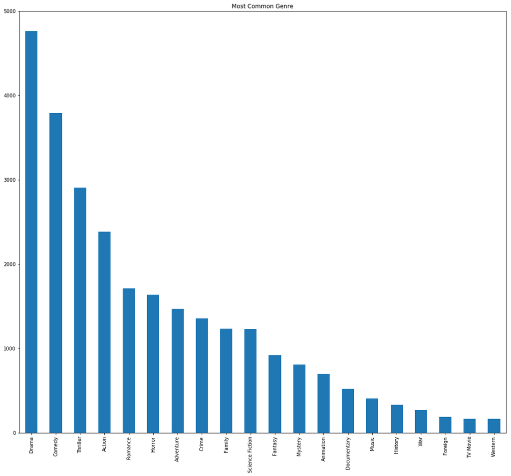

```python
#Chart to show the most common genrea through out the total data set
%matplotlib inline
genre_count.plot.bar(figsize=(18, 16),title=('Most Common Genre'))
```

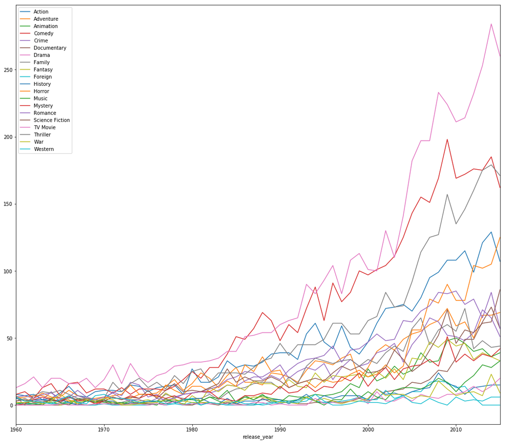

```python
#plot the occurance of each genre per year
%matplotlib inline
genre_answer.plot.line(figsize=(18,16))
```

Conclusion:

1d analysis - Drama is the most popular genre of the time period.

2d analysis - The most popular genre by year is drama except for the following years where it is comedy (1963, 1966, 1967, 1985, 1987 , 1988, 1989, 1994,2001, 2003)

The answer to the question over all is Drama is the most common genre. The table "genre_answer" shows for each year which was the most popular genre.